# EasyVisa Project

## Context:

Business communities in the United States are facing high demand for human resources, but one of the constant challenges is identifying and attracting the right talent, which is perhaps the most important element in remaining competitive. Companies in the United States look for hard-working, talented, and qualified individuals both locally as well as abroad.

The Immigration and Nationality Act (INA) of the US permits foreign workers to come to the United States to work on either a temporary or permanent basis. The act also protects US workers against adverse impacts on their wages or working conditions by ensuring US employers' compliance with statutory requirements when they hire foreign workers to fill workforce shortages. The immigration programs are administered by the Office of Foreign Labor Certification (OFLC).

OFLC processes job certification applications for employers seeking to bring foreign workers into the United States and grants certifications in those cases where employers can demonstrate that there are not sufficient US workers available to perform the work at wages that meet or exceed the wage paid for the occupation in the area of intended employment.

## Objective:

In FY 2016, the OFLC processed 775,979 employer applications for 1,699,957 positions for temporary and permanent labor certifications. This was a nine percent increase in the overall number of processed applications from the previous year. The process of reviewing every case is becoming a tedious task as the number of applicants is increasing every year.

The increasing number of applicants every year calls for a Machine Learning based solution that can help in shortlisting the candidates having higher chances of VISA approval. OFLC has hired your firm EasyVisa for data-driven solutions. You as a data scientist have to analyze the data provided and, with the help of a classification model:

- Facilitate the process of visa approvals.
- Recommend a suitable profile for the applicants for whom the visa should be certified or denied based on the drivers that significantly influence the case status.

## Data Description

The data contains the different attributes of the employee and the employer. The detailed data dictionary is given below.

- case_id: ID of each visa application
- continent: Information of continent the employee
- education_of_employee: Information of education of the employee
- has_job_experience: Does the employee has any job experience? Y= Yes; N = No
- requires_job_training: Does the employee require any job training? Y = Yes; N = No
- no_of_employees: Number of employees in the employer's company
- yr_of_estab: Year in which the employer's company was established
- region_of_employment: Information of foreign worker's intended region of employment in the US.
- prevailing_wage: Average wage paid to similarly employed workers in a specific occupation in the area of intended employment. The purpose of the prevailing wage is to ensure that the foreign worker is not underpaid compared to other workers offering the same or similar service in the same area of employment.
- unit_of_wage: Unit of prevailing wage. Values include Hourly, Weekly, Monthly, and Yearly.
- full_time_position: Is the position of work full-time? Y = Full Time Position; N = Part Time Position
- case_status: Flag indicating if the Visa was certified or denied

## Importing necessary libraries and data

```python
#importing libraries
import pandas as pd
import numpy as np
from sklearn import metrics, tree
import matplotlib.pyplot as plt
%matplotlib inline
import warnings
warnings.filterwarnings('ignore')
import seaborn as sns
from sklearn.model_selection import train_test_split
from sklearn.linear_model import LogisticRegression
from sklearn.tree import DecisionTreeClassifier
from sklearn.model_selection import GridSearchCV
from sklearn.ensemble import BaggingClassifier, RandomForestClassifier,AdaBoostClassifier, GradientBoostingClassifier, StackingClassifier
```

## Data Overview

- Observations
- Sanity checks

```python
visa = pd.read_csv('EasyVisa.csv')
```

```python
#checking the shape of the data
visa.shape
```

```
(25480, 12)
```

There are 25480 rows and 12 columns in the dataset

```python
#printing the first 5 rows of the data
visa.head()
```

|  | case_id | continent | education_of_employee | has_job_experience | requires_job_training | no_of_employees | yr_of_estab | region_of_employment | prevailing_wage | unit_of_wage | full_time_position | case_status |
| --- | --- | --- | --- | --- | --- | --- | --- | --- | --- | --- | --- | --- |
| 0 | EZYV01 | Asia | High School | N | N | 14513 | 2007 | West | 592.2029 | Hour | Y | Denied |
| 1 | EZYV02 | Asia | Master's | Y | N | 2412 | 2002 | Northeast | 83425.6500 | Year | Y | Certified |
| 2 | EZYV03 | Asia | Bachelor's | N | Y | 44444 | 2008 | West | 122996.8600 | Year | Y | Denied |
| 3 | EZYV04 | Asia | Bachelor's | N | N | 98 | 1897 | West | 83434.0300 | Year | Y | Denied |
| 4 | EZYV05 | Africa | Master's | Y | N | 1082 | 2005 | South | 149907.3900 | Year | Y | Certified |

The first 5 rows of the data do not show any missing values. I will check if there are any in the entire dataset.

```python
#checking to see if any of the variable columns contain missing data
visa.isnull().any()
```

```
case_id                  False
continent                False
education_of_employee    False
has_job_experience       False
requires_job_training    False
no_of_employees          False
yr_of_estab              False
region_of_employment     False
prevailing_wage          False
unit_of_wage             False
full_time_position       False
case_status              False
dtype: bool
```

There are no missing values in the dataset. I will now check for duplicate rows in the dataset.

```python
#checking for duplicate rows
visa.duplicated().any()
```

```
False
```

Great! There are also no duplicate rows in the dataset.

```python
#printing the info of the dataset
visa.info()
```

```
<class 'pandas.core.frame.DataFrame'>
RangeIndex: 25480 entries, 0 to 25479
Data columns (total 12 columns):
 #   Column                 Non-Null Count  Dtype
---  ------                 --------------  -----
 0   case_id                25480 non-null  object
 1   continent              25480 non-null  object
 2   education_of_employee  25480 non-null  object
 3   has_job_experience     25480 non-null  object
 4   requires_job_training  25480 non-null  object
 5   no_of_employees        25480 non-null  int64
 6   yr_of_estab            25480 non-null  int64
 7   region_of_employment   25480 non-null  object
 8   prevailing_wage        25480 non-null  float64
 9   unit_of_wage           25480 non-null  object
 10  full_time_position     25480 non-null  object
 11  case_status            25480 non-null  object
dtypes: float64(1), int64(2), object(9)
memory usage: 2.3+ MB
```

There are 9 categorical variables, 2 variables with integers as values (the number of employees in the employer's company and the year of establishment of the employer's company), and one float variable (prevailing wage). I will convert the variables of 'object' dtype to 'categorical' dtype.

```python
#changing object to category dtypes and printing info again
for i in visa.select_dtypes('object').columns.to_list():
    visa[i] = visa[i].astype('category')
visa.info()
```

```
<class 'pandas.core.frame.DataFrame'>
RangeIndex: 25480 entries, 0 to 25479
Data columns (total 12 columns):
 #   Column                 Non-Null Count  Dtype
---  ------                 --------------  -----
 0   case_id                25480 non-null  category
 1   continent              25480 non-null  category
 2   education_of_employee  25480 non-null  category
 3   has_job_experience     25480 non-null  category
 4   requires_job_training  25480 non-null  category
 5   no_of_employees        25480 non-null  int64
 6   yr_of_estab            25480 non-null  int64
 7   region_of_employment   25480 non-null  category
 8   prevailing_wage        25480 non-null  float64
 9   unit_of_wage           25480 non-null  category
 10  full_time_position     25480 non-null  category
 11  case_status            25480 non-null  category
dtypes: category(9), float64(1), int64(2)
memory usage: 2.0 MB
```

The change from object to category dtype saved at least 300 kb of memory. I will now look at the unique values of each categorical variable.

```python
#printing the summary statsitics of the data
visa.describe()
```

|  | no_of_employees | yr_of_estab | prevailing_wage |
| --- | --- | --- | --- |
| count | 25480.000000 | 25480.000000 | 25480.000000 |
| mean | 5667.043210 | 1979.409929 | 74455.814592 |
| std | 22877.928848 | 42.366929 | 52815.942327 |
| min | -26.000000 | 1800.000000 | 2.136700 |
| 25% | 1022.000000 | 1976.000000 | 34015.480000 |
| 50% | 2109.000000 | 1997.000000 | 70308.210000 |
| 75% | 3504.000000 | 2005.000000 | 107735.512500 |
| max | 602069.000000 | 2016.000000 | 319210.270000 |

What stands out most about this is the minimum number of employees, which is -26, a counterintuitive inclusion in the dataset. The mean number of employees is 5667, the median is 2109, and the max is 602,069, which indicates a heavy right skew.

For the year of establishment(which I may later convert to a category-like variable), the earliest year in which a company represented in the dataset was established is 1800 (very old!), while the latest year in which a company represented in the dataset was established is 2016 (very new, especially considering this is the year the dataset was generated). The median date of establishment was 1997, while the mean date of establishment was 1979, which indicates that the data for this variable as a leftward skew, though perhaps not too severe.

For the prevailing wage variable, the values in this column are tricky because they are based on either hourly, monthly, weekly, or yearly compensation, so I may need to convert all of this data to one scale before performing my analysis. To make the most basic observation about this column, however, the minimum value of this variable is 2.13 (dollars, presumably, as this is a dataset for the US), the maximum value is 319210, the median value is 70308.21, and the mean value is 74455.81, which indicates a slight right skew.

```python
#printing the unqiue values of each categorical variable
cat_cols = visa.select_dtypes('category').columns.to_list()
for i in cat_cols:
    print("Unique values in", i, "are :")
    print(visa[i].value_counts(),'\n')
    print('There are',len(visa[i].value_counts()),'values for this variable.' )
    print("*" * 50)
```

```
Unique values in case_id are :
EZYV01       1
EZYV25287    1
EZYV25285    1
EZYV25284    1
EZYV25283    1
            ..
EZYV17633    1
EZYV17632    1
EZYV17631    1
EZYV17630    1
EZYV9999     1
Name: case_id, Length: 25480, dtype: int64

There are 25480 values for this variable.
Unique values in continent are :
Asia             16861
Europe            3732
North America     3292
South America      852
Africa             551
Oceania            192
Name: continent, dtype: int64

There are 6 values for this variable.
Unique values in education_of_employee are :
Bachelor's     10234
Master's        9634
High School     3420
Doctorate       2192
Name: education_of_employee, dtype: int64

There are 4 values for this variable.
Unique values in has_job_experience are :
Y    14802
N    10678
Name: has_job_experience, dtype: int64

There are 2 values for this variable.
Unique values in requires_job_training are :
```

[output cut: 19 more lines]

```
Name: unit_of_wage, dtype: int64

There are 4 values for this variable.
Unique values in full_time_position are :
Y    22773
N     2707
Name: full_time_position, dtype: int64

There are 2 values for this variable.
Unique values in case_status are :
Certified    17018
Denied        8462
Name: case_status, dtype: int64

There are 2 values for this variable.
```

The case_id variables has as many unique values as there are rows in the dataset, so I will drop this variable when I perform later analysis. There are 6 unique values for the continent variable, 5 unique values for the region_of_employment variable, 4 unique values for the unit of wage and education variables, and 2 unqiue values for the variables case_status(target variable), full time position (Y/N), requires job training (Y/N), and has job experience (Y/N). I may convert the ones with two unique values to ones and zeros for building my classification model.

Luckily, there are no "unknown" or "missing" values in any of these variables, so we will not have to impute values into them. This will lighten the load in preparing the data for analysis and model building.

## Exploratory Data Analysis (EDA)

I first want to drop the case_id variable from the dataset, as it will not be useful in generating the model.

```python
#making a copy of visa dataset by dropping case_id
visa = visa.drop('case_id', axis = 1).copy()
```

```python
#printing the head of the new dataset
visa.head()
```

|  | continent | education_of_employee | has_job_experience | requires_job_training | no_of_employees | yr_of_estab | region_of_employment | prevailing_wage | unit_of_wage | full_time_position | case_status |
| --- | --- | --- | --- | --- | --- | --- | --- | --- | --- | --- | --- |
| 0 | Asia | High School | N | N | 14513 | 2007 | West | 592.2029 | Hour | Y | Denied |
| 1 | Asia | Master's | Y | N | 2412 | 2002 | Northeast | 83425.6500 | Year | Y | Certified |
| 2 | Asia | Bachelor's | N | Y | 44444 | 2008 | West | 122996.8600 | Year | Y | Denied |
| 3 | Asia | Bachelor's | N | N | 98 | 1897 | West | 83434.0300 | Year | Y | Denied |
| 4 | Africa | Master's | Y | N | 1082 | 2005 | South | 149907.3900 | Year | Y | Certified |

I have removed the case_id variable from the dataset. I will now define helpful functions that will assist in EDA before I continue to EDA.

```python
# labeled barplot function


def labeled_barplot(data, feature, perc=False, n=None):
    """
    Barplot with percentage at the top

    data: dataframe
    feature: dataframe column
    perc: whether to display percentages instead of count (default is False)
    n: displays the top n category levels (default is None, i.e., display all levels)
    """

    total = len(data[feature])  # length of the column
    count = data[feature].nunique()
    if n is None:
        plt.figure(figsize=(count + 1, 5))
    else:
        plt.figure(figsize=(n + 1, 5))

    plt.xticks(rotation=90, fontsize=15)
    ax = sns.countplot(
        data=data,
        x=feature,
        palette="Paired",
        order=data[feature].value_counts().index[:n].sort_values(),
    )

    for p in ax.patches:
        if perc == True:
            label = "{:.1f}%".format(
                100 * p.get_height() / total
            )  # percentage of each class of the category
        else:
            label = p.get_height()  # count of each level of the category

        x = p.get_x() + p.get_width() / 2  # width of the plot
        y = p.get_height()  # height of the plot

        ax.annotate(
            label,
            (x, y),
            ha="center",
            va="center",
            size=12,
            xytext=(0, 5),
            textcoords="offset points",
        )  # annotate the percentage

    plt.show()  # show the plot
```

**1.1 Univariate Analysis**

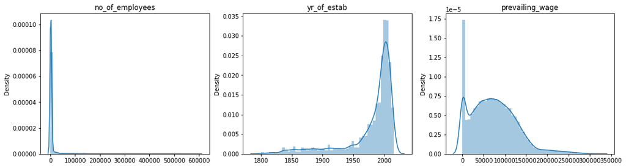

```python
#plotting displots for all of the numerical variables
num_cols = ['no_of_employees', 'yr_of_estab', 'prevailing_wage']
a = 1
plt.figure(figsize = (30,15));
for i in visa[num_cols]:
    plt.subplot(3,5,a);
    if a < len(num_cols):
        sns.distplot(visa[i]);
        plt.title(label = str(i));
        plt.xlabel(xlabel = str(''));
        a = a+1
    elif a == len(num_cols):
        sns.distplot(visa[i], kde = True);
        plt.title(label = str(i))
        plt.xlabel(xlabel = str(''))
```

As mentioned earlier, the distribution of number of employees ahs a heavy right skew. The year of establishment has a heavy left skew, indicating, as assumed earlier, that most of the companies represented in the dataset were established more recently. As mentioned earlier, the distribution of the prevailing wage may be a bit misleading, as the rate of compensation will be different for monthly, yearly, hourly, and weekly wages. WHat we can see from this distribution plot, however, is that many values hover just above 0, but disregarding that, the compensation appears to follow what could be a normal distribution around the 75000 dollar mark. Again, this is disregarding that strange spike on the lower side of the distribution. I will look at the boxplots of these as well.

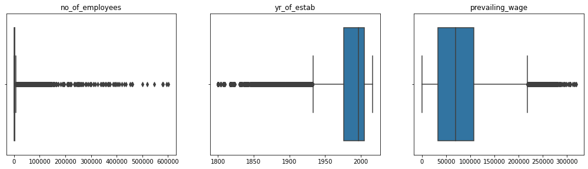

```python
#plotting the boxplots of the above
a = 1
plt.figure(figsize = (30,15));
for i in visa[num_cols]:
    plt.subplot(3,5,a);
    if a < len(num_cols):
        sns.boxplot(visa[i]);
        plt.title(label = str(i));
        plt.xlabel(xlabel = str(''));
        a = a+1
    elif a == len(num_cols):
        sns.boxplot(visa[i]);
        plt.title(label = str(i))
        plt.xlabel(xlabel = str(''))
```

As we can see from these boxplots, there are many outliers in the number of employees variable, so many that the IQR and even the whiskers appear to be very close in value. This may have an impact on the model, and I may have to clip some of these outliers before I build the model.

The year of establishment, as predicted, has many outliers below the lower whisker and none above the higher, which indicates that there are many values that may need to be clipped from this variable as well, unless I can determine that these have a bearing on certification or denial status.

There are also many outliers on the higher end of the prevailing wage variable. I suspect, though, that a higher wage will have an impact on whether or not an applicant's visa will be certified, so I may leave that alone in my preprocessing.

I am curious about the firm that had negative employees. I will briefly check how many firms there are with negative employees.

```python
#printing firms with no_of_employees<0
len(visa[visa['no_of_employees'] < 0])
```

```
33
```

There are 33 firms with negative employees. This is counterintuitive, and I will probably need to remove these from the dataset or manipulate the data so that it does not skew the model results. I will now do a brief univariate analysis of the categorical columns.

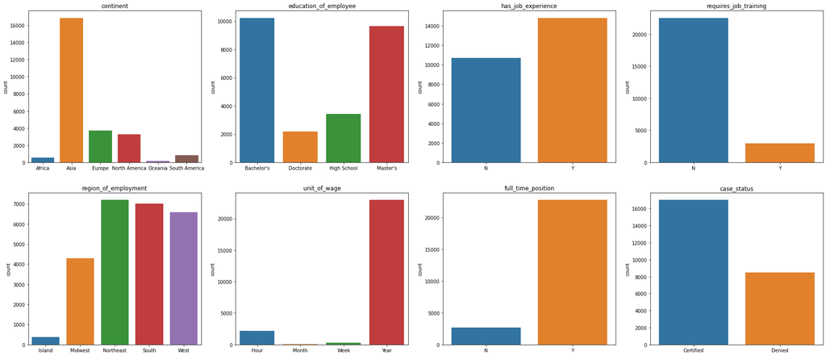

```python
#printing countplots of the categorical columns
cat_cols = visa.select_dtypes('category').columns.to_list()
a = 1
plt.figure(figsize = (30,20));
for i in visa[cat_cols]:
    plt.subplot(3,4,a);
    if a < len(cat_cols):
        sns.countplot(visa[i]);
        plt.title(label = str(i));
        plt.xlabel(xlabel = str(''));
        a = a+1
    elif a == len(cat_cols):
        sns.countplot(visa[i]);
        plt.title(label = str(i))
        plt.xlabel(xlabel = str(''))
```

There is a lot to unpack here. Exact numbers are in the list above.

Applicants with Bachelor's and Master's degrees were highest, at just over 10000 and 9500 respectively. There is then a sharp dip to high school, with just under 4000 applicants attaining this level of education. Finally, the number of applicants with a doctorate looks to be just over 2000.

More applicants have experience than do not, although a surprising amount, about 10500, have applied for a visa without any experience. The overwhelming majority of applicants, at around 23000, have applied to positions for which they will not require job training.

The most applicants (just over 7000) have applied to the Northeat region of the US, followed by the South with around 7000, then the West just below that at what looks like 6500. There is then a steep drop to applications to the Midwest, which amounts to about 4200 rows in the dataset. Finally, there were only around 400 applications to work on an island which is part of the US.

Most of the applicants will be paid a yearly wage. I may hvae to convert the other units of wage to a yearly value to change the distribution to better reflect the actual distribution in terms of the yearly value of the contract.

More than 20000 applicants will be working full time. Finally, most of the cases in the dataset (over 16000) were certified, while only around 9000 were denied.

I will do some deeper analysis of the target variable and what I think the other determinative variables will be.

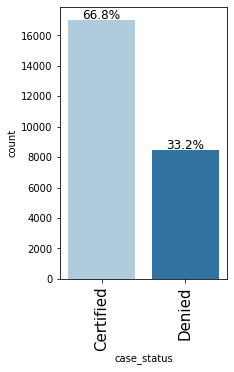

```python
labeled_barplot(visa, 'case_status', perc = True)
```

66.8% of the visas are certified while only 33.2% are denials.

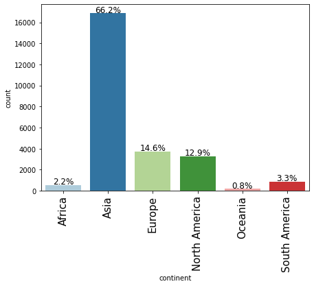

```python
labeled_barplot(visa, 'continent', perc = True)
```

66.2% of the applicants are from Asia, 14.6% are from Europe, 12.9% are from North America, 3,3% are from South America, 2.2% are from Africa, and 0.8% are from Oceania.

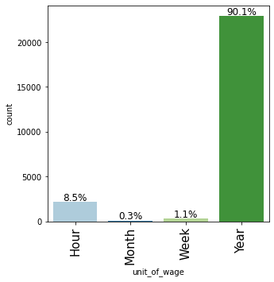

```python
labeled_barplot(visa, 'unit_of_wage', perc = True)
```

90% of the prevailing wages are yearly compensations, 8.5% are hourly, 1.1% are weekly and 0.3% are monthly.

**1.2 Bivariate/Multivariate Analysis**

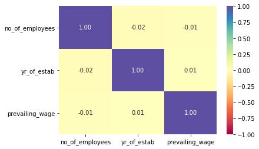

```python
#plotting a heatmap of the numerical variables
sns.heatmap(visa.corr(), annot=True, vmin=-1, vmax=1, fmt=".2f", cmap="Spectral");
plt.show();
```

None of the numeric variables are highly correlated with others.

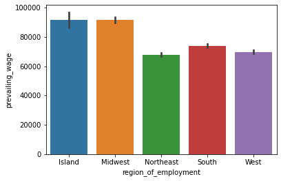

```python
#barplot showing average prevailing wage per region of US
sns.barplot(x = visa.region_of_employment, y = visa.prevailing_wage);
```

```python
#printing a representation of the above
wage_per_region = visa.groupby('region_of_employment').prevailing_wage.mean().sort_values()
print('The average prevailing wage per US region is:', round(wage_per_region,2))
```

```
The average prevailing wage per US region is: region_of_employment
Northeast    67872.66
West         69832.63
South        74040.55
Midwest      91696.74
Island       91712.75
Name: prevailing_wage, dtype: float64
```

It appears the Northeast has the lowest average prevailing wage at 67,872. The highest prevailing wage is on an island, which is to be expected, as the cost of the living there tends to be much higher. It is surprising that the prevailing wage is lowest in the Northeast, as the average cost of living there tends to be higher than in the South or Midwest.

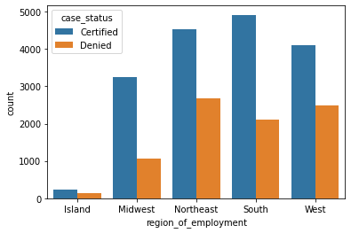

```python
#countplot of case status by region
sns.countplot(x = visa.region_of_employment, hue = visa.case_status);
```

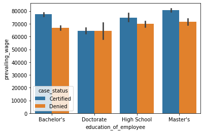

```python
#barplot on education with prevailing wage and case status
sns.barplot(x=visa.education_of_employee, y = visa.prevailing_wage, hue = visa.case_status);
```

Interestingly, the average prevailing wage for different levels of education does not vary much, as all values are between just over 80000 dollars and around 65000 dollars. This is very surprising. It is also surprising that the average wage for high-school-educated applicants is higher than that for applicants with a doctorate, as I would assume compensation and education level are generally positively correlated.

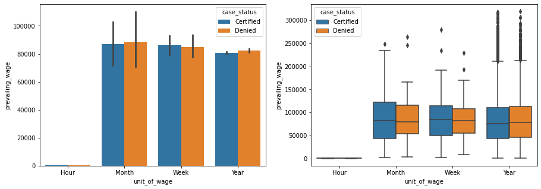

```python
# barplot and boxplot of unit of wage on prevailing wage considering case status
plt.figure(figsize = (15,5));
plt.subplot(1,2,1);
sns.barplot(x = visa.unit_of_wage, y = visa.prevailing_wage, hue = visa.case_status);
plt.subplot(1,2,2);
sns.boxplot(x = visa.unit_of_wage, y = visa.prevailing_wage, hue = visa.case_status);
```

```python
#printing average hourly wage
visa.groupby('unit_of_wage').prevailing_wage.mean()
```

```
unit_of_wage
Hour       414.570513
Month    87592.864045
Week     85606.820515
Year     81228.077133
Name: prevailing_wage, dtype: float64
```

There is a lot that is counterintuitive in this visualization, which I suspect is a result of incorrectly submitted or poorly defined data.

The average hourly wage is 414 dollars (exceedingly high by American standards), and the rest of the wages are equal in value, which is also surprising, as I expected the wages to be by unit, which it seems they are not. If they were, yearly would be higher than monthly would be higher than weekly would be higher than hourly. I initially suspected I would be treating this data, but I might not.

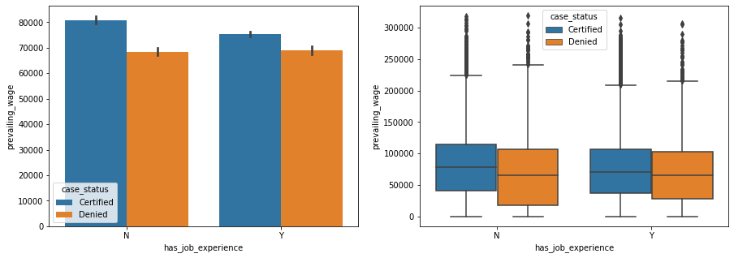

```python
#showing a barplot and boxplot of job status on prevailing wage with case status
plt.figure(figsize = (15,5));
plt.subplot(1,2,1);
sns.barplot(x = visa.has_job_experience, y = visa.prevailing_wage, hue = visa.case_status);
plt.subplot(1,2,2);
sns.boxplot(x = visa.has_job_experience, y = visa.prevailing_wage, hue = visa.case_status);
```

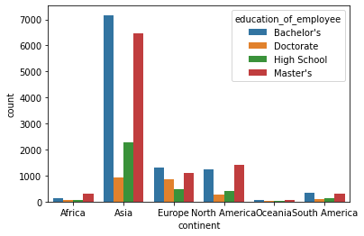

```python
#countplot of education by continent
sns.countplot(visa.continent, hue = visa.education_of_employee);
```

From all continents, it appears the most common levels of education achieved are Bachelor's and Master's.

Europe is the only continent that has a larger amount of doctorate-holder applicants than high-school-diploma-holding applicants.

Applicants from Asia have a high proportion of Bachelor's and Master's degrees. The number of applicants with doctorates from Europe is almost equal to the number that have doctorates from Asia. Since the number of applicants from Europe is much smaller than the number from Asia, this shows that the proportion of applicant's with doctorates from Europe is much higher than that from Asia. It is safe to say that European applicants have the highest proportion of doctorates among all continents. This might have a bearing on European approval status.

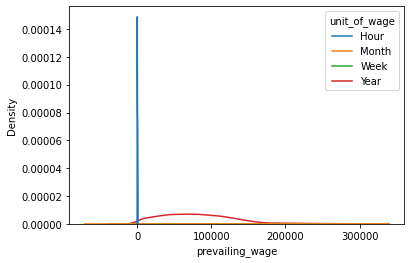

```python
sns.kdeplot(visa.prevailing_wage, hue = visa.unit_of_wage);
```

This shows why the distribution of the prevailing wage variable is so skewed. The hourly compensation is clustered towards the bottom of the distribution, which is to be expected.

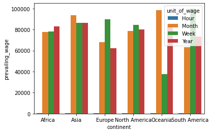

```python
sns.barplot(x = visa.continent, y = visa.prevailing_wage, hue = visa.unit_of_wage, ci = None);
```

```python
visa.groupby('unit_of_wage').prevailing_wage.max()
```

```
unit_of_wage
Hour        999.9195
Month    264362.9500
Week     280175.9500
Year     319210.2700
Name: prevailing_wage, dtype: float64
```

The monthly, weekly, and yearly values are all 6 figures, while the max hourly value is 1000. It is not inconceivable that this would be an hourly compensation, but I will try to manipulate the data such that the distribution is not so skewed.

### Leading Questions:

**1. Those with higher education may want to travel abroad for a well-paid job. Does education play a role in Visa certification?**

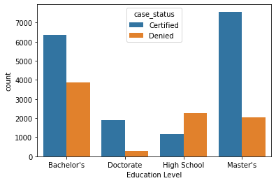

```python
#countplot to show this question
sns.countplot(visa.education_of_employee, hue = visa.case_status);
plt.xlabel('Education Level');
```

All but one of the education levels have a higher amount of certified statuses than denied statuses. Those with only a high-school level of educaiton seem more likely to have their cases denied than certified. Those with a Bachelor's degree of a good chance of having their cases certified, while those with Master's degrees and Doctorates appear to have the highest certification-to-denial rates.

**2. How does the visa status vary across different continents?**

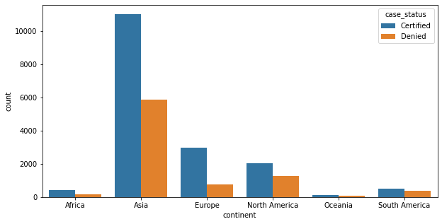

```python
#countplot to see how many visas per continent denied v. certified
plt.figure(figsize = (10,5))
sns.countplot(visa.continent, hue = visa.case_status);
```

The highest number of certified visas come from Asia, followed by Europe, North America, South America, Africa, and finally Oceania. The number of denied visas, in descending order, are from Asia, North America, Europe, South America, Africa and Oceania. Europe appears to have the highest certified-to-denied rate, while South America and Oceania appear to have the lowest certified-to-denied rate. All continents saw more visas certified than denied.

**3. Experienced professionals might look abroad for opportunities to improve their lifestyles and career development. Does work experience influence visa status?**

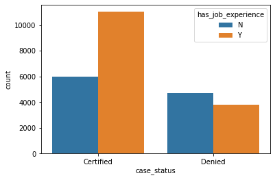

```python
#countplot to show visa status on work experience
sns.countplot(visa.case_status, hue = visa.has_job_experience);
```

**4. In the United States, employees are paid at different intervals. Which pay unit is most likely to be certified for a visa?**

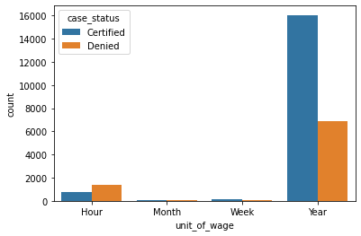

```python
#countplot to show unit of wage on case status
sns.countplot(visa.unit_of_wage, hue = visa.case_status);
```

This graph clearly shows that the pay unit most likely to be certified for a visa is the yearly pay unit. Those applicants who are compensated hourly appear most likely to have their applications denied.

**5. The US government has established a prevailing wage to protect local talent and foreign workers. How does the visa status change with the prevailing wage?**

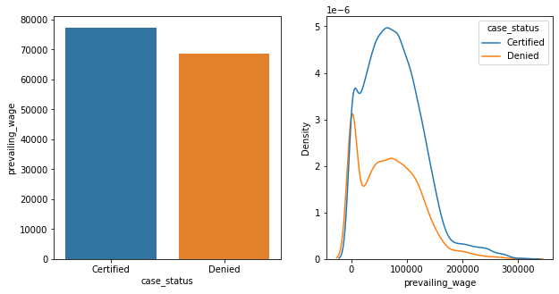

```python
#plotting barplot to show prevailing wage per visa status
plt.figure(figsize = (10,5))
plt.subplot(1,2,1);
sns.barplot(x = visa.case_status, y = visa.prevailing_wage, ci = None);
plt.subplot(1,2,2);
sns.kdeplot(visa.prevailing_wage, hue = visa.case_status);
```

This barplot indicates that the average prevailing wage is higher for certified visas than denied visas by about 10,000 dollars. Given that yearly compensation dominates the dataset, it is safe to assume that this is a yearly difference. The kdeplot shows that there is a greater proportion of higher wages for certified versus denied visas, and that there is a greater proportion of low prevailing wages among the visas that were denied.

## Data Preprocessing

- Missing value treatment is not needed, as there are no missing values
- Feature engineering is needed, and I will elaborate on which ones are as I progress
- Outlier detection and treatment: I have already detected some outliers, so I may treat them so that they do not have too much of an effect on the model results.

First, I will engineer the target variable so that the two classes, certified and denied, become 1 and 0 respectively.

```python
#changing the values in the target variable. certified = denied = 0
visa['case_status'] = visa['case_status'].replace({'Certified': 1, 'Denied':0})
#printing the value counts to see if the change was made
visa.case_status.value_counts()
```

```
1    17018
0     8462
Name: case_status, dtype: int64
```

1s and 0s have replaced certifieds and denieds. I will now change the wages to reflect yearly compensation instead of the rate at which they are paid. That way I will still have comparable dollar figures for all positions. I will also retain the rate at which each applicant is paid (i.e. monthly, hourly, etc.), as this may be determinative for whether or not a visa application is certified.

```python
#printing the number of times each value of unit_of_wage is represented
visa.unit_of_wage.value_counts()
```

```
Year     22962
Hour      2157
Week       272
Month       89
Name: unit_of_wage, dtype: int64
```

I will leave the values of the yearly wage untouched. I will multiply the value of the monthly wage times 12. I will multiply the value in the weekly wage by 52, and I will mutliply the value of the hourly wage by 52x40(weeks x hr/wk), or 2080. First, though, I want to see if value of the prevailing wage column makes sense given the value in that unit_of_wage column row.

```python
#locating the prevailing wage for hourly wage units
hour = visa.loc[visa['unit_of_wage'] == 'Hour', 'prevailing_wage']
print(hour.head())
print(hour.max())
print(hour.min())
```

```
0     592.2029
7     418.2298
54    230.8072
62    103.2216
70    230.3270
Name: prevailing_wage, dtype: float64
999.9195
2.1367
```

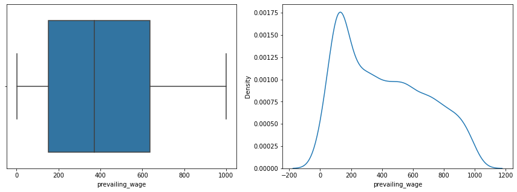

```python
#showing a kde plot and boxplot of the hourly wage
plt.figure(figsize = (15,5))
plt.subplot(1,2,1);
sns.boxplot(hour);
plt.subplot(1,2,2);
sns.kdeplot(hour);
```

There are no outliers for the low hourly wages. The distribution is not normal, though.

```python
#locating the prevailing wage for weekly wage units
week = visa.loc[visa['unit_of_wage'] == 'Week', 'prevailing_wage']
print(week.head())
print(week.max())
print(week.min())
```

```
113    98966.72
116    32400.20
169    71825.63
243    62112.22
365    67492.78
Name: prevailing_wage, dtype: float64
280175.95
2183.23
```

After checking these, I can tell that this is clearly not the weekly wage. I will check the values for monthly prevailing wages to see if a similar problem emerges.

```python
#locating the prevailing wage for monthly wage units
month = visa.loc[visa['unit_of_wage'] == 'Month', 'prevailing_wage']
print(month.head())
print(month.max())
```

```
220    141796.39
241     56606.54
438     88925.59
498     97931.99
540     82793.80
Name: prevailing_wage, dtype: float64
264362.95
```

These are also clearly not monthly wages. I will check some of the lower values of the prevailing wage column to see if there is a pattern to their unit of wage.

```python
#showing the row where the prevailing wage is lowest
visa[visa['prevailing_wage'] == visa['prevailing_wage'].min()]
```

|  | continent | education_of_employee | has_job_experience | requires_job_training | no_of_employees | yr_of_estab | region_of_employment | prevailing_wage | unit_of_wage | full_time_position | case_status |
| --- | --- | --- | --- | --- | --- | --- | --- | --- | --- | --- | --- |
| 20575 | North America | Master's | N | N | 1552 | 2004 | Northeast | 2.1367 | Hour | Y | 1 |

The minimum prevailing wage comes in at 2.1367/hr. This candidate has a Master's Degree. It is inconceivable that this is the case, and I can only assume that this entry is erroneous.

```python
#printing the values in the prevailing wage column that are below Q1
print(f'The Q1 value of the previaling_wage variable equals {visa.prevailing_wage.quantile(0.25)}.')
low_wage = visa[visa['prevailing_wage'] < visa['prevailing_wage'].quantile(0.25)]
print(f'There are {len(low_wage)} values below Q1 in the prevailing wage column.')
```

```
The Q1 value of the previaling_wage variable equals 34015.479999999996.
There are 6370 values below Q1 in the prevailing wage column.
```

There are 6370 rows out of the 25480, or about 1/4 of them, that have wages below the value at Q1. I will print the head of this selection to see what unit_of_wage each has.

```python
#printing the head of the low_wage subset of the original dataset
low_wage.head()
```

|  | continent | education_of_employee | has_job_experience | requires_job_training | no_of_employees | yr_of_estab | region_of_employment | prevailing_wage | unit_of_wage | full_time_position | case_status |
| --- | --- | --- | --- | --- | --- | --- | --- | --- | --- | --- | --- |
| 0 | Asia | High School | N | N | 14513 | 2007 | West | 592.2029 | Hour | Y | 0 |
| 7 | North America | Bachelor's | Y | N | 3035 | 1924 | West | 418.2298 | Hour | Y | 0 |
| 12 | Asia | Bachelor's | Y | N | 123876 | 1963 | Northeast | 28663.0500 | Year | Y | 1 |
| 16 | Europe | Master's | Y | N | 76638 | 1991 | Midwest | 3706.7900 | Year | Y | 1 |
| 17 | Asia | Master's | Y | N | 2747 | 2001 | West | 16132.6100 | Year | Y | 1 |

I can see that there are some yearly wage positions in here, and that it is reasonable that they would compensate them below this amount (though 3706 seems low for a yearly wage; perhaps there are other factors about the position that are not captured about this dataset). I will see how many times each unit of wage is represented in this subset.

```python
#checking the value counts of unit_of_wage in low_wage
low_wage.unit_of_wage.value_counts()
```

```
Year     4163
Hour     2157
Week       33
Month      17
Name: unit_of_wage, dtype: int64
```

Surprisingly, the number of hourly wages in this subset is equal to the number of hourly wages in the initial dataframe. The number of yearly, weekly and monthly wages is significantly reduced, as I expected.

However, given that only a few of the values appear to reflect a non-yearly prevailing wage, I will leave them in the dataset, as it might be the case that the prevailing for that position (which is unfortunately not given in the dataset), could be low.

I will now manipulate the no_of_employees variable, as it appears to have negative values, which makes no sense.

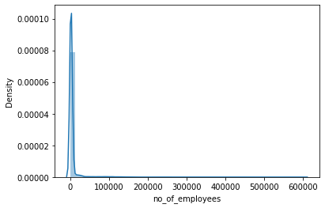

```python
#showing the distplot of no_of_employees
sns.distplot(visa.no_of_employees);
```

```python
#printing the summary statistics of this variable
visa.describe().no_of_employees
```

```
count     25480.000000
mean       5667.043210
std       22877.928848
min         -26.000000
25%        1022.000000
50%        2109.000000
75%        3504.000000
max      602069.000000
Name: no_of_employees, dtype: float64
```

```python
#showing the rows where the number of employees is less than or equal to 0
visa[visa['no_of_employees'] <= 0]
```

|  | continent | education_of_employee | has_job_experience | requires_job_training | no_of_employees | yr_of_estab | region_of_employment | prevailing_wage | unit_of_wage | full_time_position | case_status |
| --- | --- | --- | --- | --- | --- | --- | --- | --- | --- | --- | --- |
| 245 | Europe | Master's | N | N | -25 | 1980 | Northeast | 39452.9900 | Year | Y | 1 |
| 378 | Asia | Bachelor's | N | Y | -11 | 2011 | Northeast | 32506.1400 | Year | Y | 0 |
| 832 | South America | Master's | Y | N | -17 | 2002 | South | 129701.9400 | Year | Y | 1 |
| 2918 | Asia | Master's | Y | N | -26 | 2005 | Midwest | 112799.4600 | Year | Y | 1 |
| 6439 | Asia | Bachelor's | N | N | -14 | 2013 | South | 103.9700 | Hour | Y | 0 |
| 6634 | Asia | Bachelor's | Y | N | -26 | 1923 | West | 5247.3200 | Year | Y | 0 |
| 7224 | Europe | Doctorate | N | N | -25 | 1998 | Midwest | 141435.9500 | Year | Y | 1 |
| 7281 | Asia | High School | N | N | -14 | 2000 | Midwest | 58488.5000 | Year | Y | 0 |
| 7318 | Asia | Bachelor's | Y | Y | -26 | 2006 | South | 115005.6100 | Year | Y | 1 |
| 7761 | Asia | Master's | N | N | -11 | 2009 | Midwest | 38457.5100 | Year | Y | 1 |
| 9872 | Europe | Master's | Y | N | -26 | 1996 | South | 37397.0500 | Year | Y | 1 |
| 11493 | Asia | High School | Y | N | -14 | 1999 | South | 27599.3500 | Year | Y | 0 |
| 13471 | North America | Master's | N | N | -17 | 2003 | Northeast | 257.2413 | Hour | Y | 0 |
| 14022 | Asia | Bachelor's | N | Y | -11 | 1946 | Northeast | 108403.5600 | Year | Y | 1 |
| 14146 | Asia | Bachelor's | N | Y | -26 | 1954 | West | 81982.2700 | Year | Y | 1 |
| 14726 | Asia | Master's | N | N | -11 | 2000 | Midwest | 167851.8000 | Year | Y | 1 |
| 15600 | Asia | Bachelor's | N | N | -14 | 2014 | South | 24641.6100 | Year | Y | 0 |
| 15859 | Asia | High School | N | N | -11 | 1969 | South | 44640.6000 | Year | Y | 0 |
| 16157 | Asia | Master's | Y | N | -11 | 1994 | South | 62681.2500 | Year | Y | 1 |
| 16883 | North America | Bachelor's | Y | N | -26 | 1968 | Northeast | 168.1558 | Hour | Y | 0 |
| 17006 | Asia | Doctorate | Y | N | -11 | 1984 | West | 25753.5100 | Year | Y | 0 |
| 17655 | North America | Bachelor's | Y | N | -17 | 2007 | Northeast | 129753.1800 | Year | Y | 0 |
| 17844 | Asia | Bachelor's | N | N | -14 | 2012 | West | 29325.8500 | Year | Y | 0 |
| 17983 | Asia | Bachelor's | N | N | -26 | 2004 | South | 84359.9800 | Year | Y | 0 |
| 20815 | Asia | Bachelor's | N | Y | -17 | 1990 | West | 91897.5700 | Year | Y | 1 |
| 20984 | Europe | Doctorate | Y | N | -14 | 1989 | Midwest | 37012.8000 | Year | Y | 1 |
| 21255 | North America | High School | N | N | -25 | 1987 | South | 99405.4700 | Year | N | 0 |
| 21760 | Asia | Bachelor's | Y | N | -25 | 2000 | West | 100463.5800 | Year | Y | 1 |
| 21944 | Africa | Master's | Y | N | -25 | 1977 | Midwest | 79150.5100 | Year | Y | 1 |
| 22084 | North America | Bachelor's | Y | N | -14 | 1980 | West | 691.0609 | Hour | Y | 0 |
| 22388 | Asia | Master's | Y | N | -14 | 1986 | South | 17893.1100 | Year | Y | 1 |
| 23186 | Asia | Master's | N | Y | -11 | 2007 | Midwest | 120195.3500 | Year | Y | 1 |
| 23476 | Europe | Master's | Y | N | -11 | 2000 | West | 95072.7500 | Year | Y | 0 |

```python
#replacing negative values with median value
visa['no_of_employees'][visa['no_of_employees']<0] = visa['no_of_employees'].median()
```

```python
visa[visa['no_of_employees'] < 0]
```

|  | continent | education_of_employee | has_job_experience | requires_job_training | no_of_employees | yr_of_estab | region_of_employment | prevailing_wage | unit_of_wage | full_time_position | case_status |
| --- | --- | --- | --- | --- | --- | --- | --- | --- | --- | --- | --- |

These values have been replaced with the median.

## EDA

- It is a good idea to explore the data once again after manipulating it.

## Building bagging and boosting models

First I want to split the training data from the testing data. I will also define some functions to determine evaluation metrics and to visualize a confusion matrix.

Since the objective for this task is to find a way to shortlist candidates that have a higher chance at visa approval, I want to use the metric that will most correctly predict both true positives and true negatives (or true certifications and true denials). Finding the best recall score (TP/(TP+FN) will harm the precision score, while finding the best precision score (TP/(TP+FP) will harm the recall score. Since I want to minimize both the false positives and false negatives, I will use the f1 score as the metric for this model, as this will provide the harmonic mean between precision and recall.

The functions will also contain the accuracy, precision and recall scores for each model just for the purposes of curiosity.

**Preliminary Steps: separating data and defining performance-evaluation functions**

#### Separating the data

```python
#separating the data and performing a train_test_split
x = visa.drop('case_status', axis = 1)
y = visa['case_status']
x = pd.get_dummies(x)
x_train, x_test, y_train, y_test = train_test_split(x, y, test_size = 0.3, random_state = 1, stratify = y)
```

```python
#printing the shape of both the training and testing sets
x_train.shape, x_test.shape
```

```
((17836, 28), (7644, 28))
```

The training data has 17,836 samples across 28 variables and the testing data has 7644 samples across the same number of variables.

```python
print('The seaparation of the training set is:\n',y_train.value_counts())
```

```
The seaparation of the training set is:
 1    11913
0     5923
Name: case_status, dtype: int64
```

```python
print('The separation of the testing set is as follows:\n', y_test.value_counts())
```

```
The separation of the testing set is as follows:
 1    5105
0    2539
Name: case_status, dtype: int64
```

There are more certifications than denials in the training and testing data. Since I am trying to predict them equally, I will not adjust the class_weight parameter in the classifiers.

#### Defining functions

```python
## Function to create confusion matrix
def confusion_matrix(model,y_true,labels=[1, 0]):
    '''
    model : classifier to predict values of X
    y_actual : ground truth

    '''
    y_pred = model.predict(x_test)
    cm=metrics.confusion_matrix(y_true, y_pred, labels=[0, 1])
    df_cm = pd.DataFrame(cm, index = [i for i in ["Actual Denial","Actual Certification"]],
                  columns = [i for i in ['Predicted Denial','Predicted Certification']])
    group_counts = ["{0:0.0f}".format(value) for value in
                cm.flatten()]
    group_percentages = ["{0:.2%}".format(value) for value in
                         cm.flatten()/np.sum(cm)]
    labels = [f"{v1}\n{v2}" for v1, v2 in
              zip(group_counts,group_percentages)]
    labels = np.asarray(labels).reshape(2,2)
    plt.figure(figsize = (10,7))
    sns.heatmap(df_cm, annot=labels,fmt='')
    plt.ylabel('True label')
    plt.xlabel('Predicted label')
```

```python
##  Function to calculate different metric scores of the model - Accuracy, Recall, F1 and Precision
def metrics_score(model,flag=True):
    '''
    model : classifier to predict values of X

    '''
    # defining an empty list to store train and test results
    score_list=[]

    #Predicting on train and tests
    pred_train = model.predict(x_train)
    pred_test = model.predict(x_test)

    #Accuracy of the model
    train_acc = model.score(x_train,y_train)
    test_acc = model.score(x_test,y_test)

    #Recall of the model
    train_recall = metrics.recall_score(y_train,pred_train)
    test_recall = metrics.recall_score(y_test,pred_test)

    #Precision of the model
    train_precision = metrics.precision_score(y_train,pred_train)
    test_precision = metrics.precision_score(y_test,pred_test)

    #F1 score of the model
    train_f1 = metrics.f1_score(y_train,pred_train)
    test_f1 = metrics.f1_score(y_test,pred_test)

    score_list.extend((train_acc,test_acc,train_recall,test_recall,train_precision,test_precision,train_f1, test_f1))

    # If the flag is set to True then only the following print statements will be dispayed. The default value is set to True.
    if flag == True:
        print("Accuracy on training set : ",model.score(x_train,y_train))
        print("Accuracy on test set : ",model.score(x_test,y_test))
        print("Recall on training set : ",metrics.recall_score(y_train,pred_train))
        print("Recall on test set : ",metrics.recall_score(y_test,pred_test))
        print("Precision on training set : ",metrics.precision_score(y_train,pred_train))
        print("Precision on test set : ",metrics.precision_score(y_test,pred_test))
        print("F1 Score on the training set : ",train_f1)
        print("F1 Score on the test set : ",test_f1)

    return score_list # returning the list with train and test scores
```

### 1. Bagging Models

#### 1.1 Decision Tree

```python
#building a decision tree model and fitting it to my data
dTree = DecisionTreeClassifier(criterion = 'gini', random_state = 1)
dTree.fit(x_train, y_train)
```

```
DecisionTreeClassifier(random_state=1)
```

```python
#getting the performance metrics for the decision tree
dTree_score = metrics_score(dTree)
```

```
Accuracy on training set :  1.0
Accuracy on test set :  0.6588173731030874
Recall on training set :  1.0
Recall on test set :  0.7380999020568071
Precision on training set :  1.0
Precision on test set :  0.7477674141694781
F1 Score on the training set :  1.0
F1 Score on the test set :  0.7429022082018928
```

The accuracy on the training set is, as anticipated, 100%, whereas the accuracy on the test set is ~66%. The recall, precision and f1 score on the training set are all 100%, which indicates overfit. The f1 score, the metric I want to maximize, is .742 on the test set, which is higher than I was anticipating. I will print a confusion matrix to visualize the above.

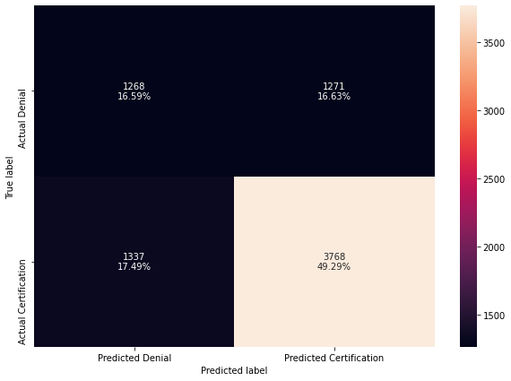

```python
#visualizing a confusion matrix for the decision tree's performance
confusion_matrix(dTree, y_test)
```

I will now display the importance of each feature from the decision tree.

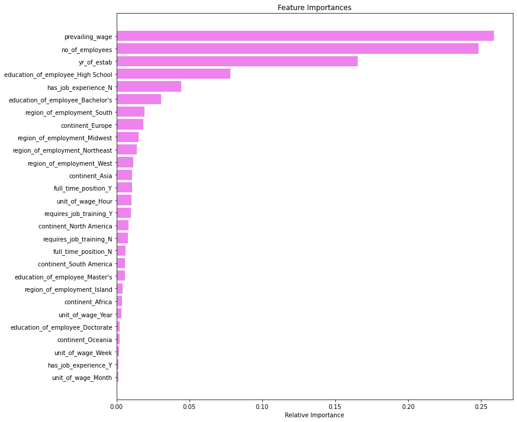

```python
#graphing the feature importances
feature_names = x_train.columns.to_list()
importances = dTree.feature_importances_
indices = np.argsort(importances)

plt.figure(figsize=(12,12))
plt.title('Feature Importances')
plt.barh(range(len(indices)), importances[indices], color='violet', align='center')
plt.yticks(range(len(indices)), [feature_names[i] for i in indices])
plt.xlabel('Relative Importance')
plt.show()
```

I can see from this graph that the top five most important features are the prevailing wage, the number of employees, the year of establishment of the business, if an applicant has a high-school education, and if the applicant has no previous job experience.

```python
#making the decision tree the classifier.
tuned_dTree = DecisionTreeClassifier(random_state=1)

#choosing the grid of parameters
parameters = {'max_depth': np.arange(1,10),
              'min_samples_leaf': [1, 2, 5, 7, 10,15,20],
              'max_leaf_nodes' : [2, 3, 5, 10],
              'min_impurity_decrease': [0.001,0.01,0.1]
             }

# Type of scoring used to compare parameter combinations
acc_scorer = metrics.make_scorer(metrics.f1_score)

# Run the grid search
grid_obj = GridSearchCV(tuned_dTree, parameters, scoring=acc_scorer,cv=5)
grid_obj = grid_obj.fit(x_train, y_train)

# Set the clf to the best combination of parameters
tuned_dTree = grid_obj.best_estimator_

# Fit the best algorithm to the data.
tuned_dTree.fit(x_train, y_train)
```

```
DecisionTreeClassifier(max_depth=4, max_leaf_nodes=10,
                       min_impurity_decrease=0.001, random_state=1)
```

```python
#printing the performance metrics for the tuned decision tree
tuned_tree_score = metrics_score(tuned_dTree)
```

```
Accuracy on training set :  0.7348060103162144
Accuracy on test set :  0.7271062271062271
Recall on training set :  0.9036346847981197
Recall on test set :  0.9020568070519099
Precision on training set :  0.7503310796682233
Precision on test set :  0.7438216766273623
F1 Score on the training set :  0.8198781416603199
F1 Score on the test set :  0.8153328611898016
```

From these results I can see that the tuned decision tree outperformed the other decision tree. It significantly reduced overfitting, as the scores for all metrics on the training and testing data are similar, and it also produced an f1 score of .815 on the test data. I will show the confusion matrix for the tuned tree and then I will see if the feature importances for the tuned tree have changed from the original.

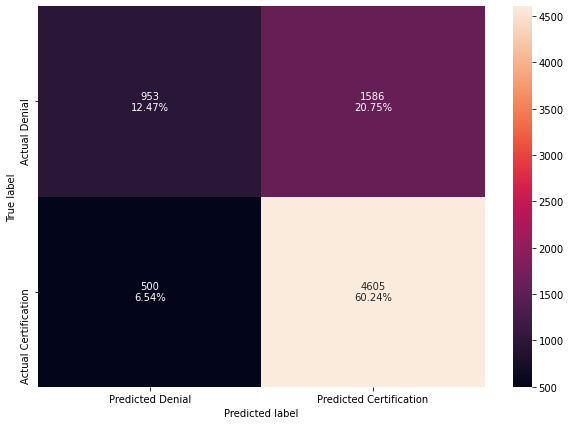

```python
#printing the confusion matrix for the tuned decision tree
confusion_matrix(tuned_dTree, y_test)
```

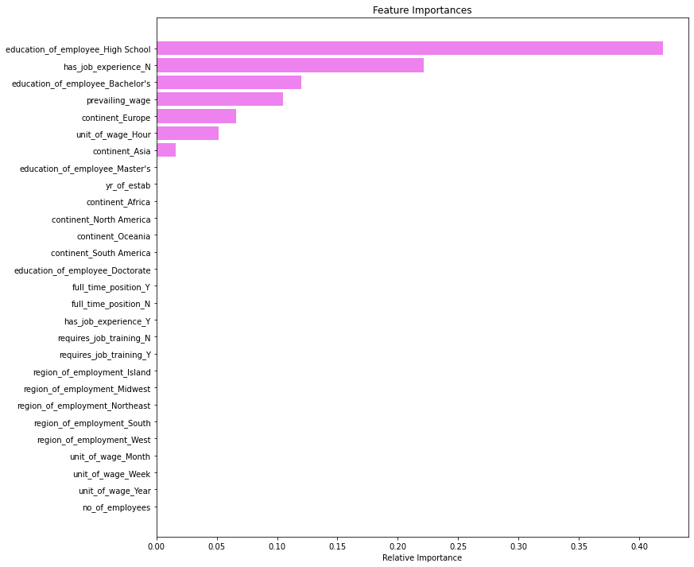

```python
#printing the feature importances of the tuned tree
importances = tuned_dTree.feature_importances_
indices = np.argsort(importances)

plt.figure(figsize=(12,12))
plt.title('Feature Importances')
plt.barh(range(len(indices)), importances[indices], color='violet', align='center')
plt.yticks(range(len(indices)), [feature_names[i] for i in indices])
plt.xlabel('Relative Importance')
plt.show()
```

Very surprisingly, in the tuned decision tree, prevailing wage has moved to fourth place in terms of importance for determining certification or denial. The most important feature is if the applicant has only a high school education, if they do not have job experience, if they have up to a Bachelor's education, the prevailing wage, and if they apply from Europe.

I will now go on to build the bagging classifier.

#### 1.2 Bagging Classifier

```python
#building a bagging classifier for the model
bag = BaggingClassifier(random_state = 1)
bag.fit(x_train,y_train)
```

```
BaggingClassifier(random_state=1)
```

```python
#getting the performance metrics for the bagging classifier
bag_score = metrics_score(bag)
```

```
Accuracy on training set :  0.9835725498990805
Accuracy on test set :  0.7009419152276295
Recall on training set :  0.9845546881557962
Recall on test set :  0.7745347698334966
Precision on training set :  0.9907923635749282
Precision on test set :  0.7769699351542543
F1 Score on the training set :  0.9876636773188496
F1 Score on the test set :  0.7757504414361389
```

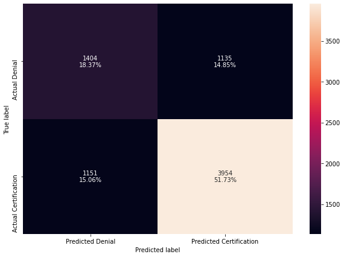

```python
#visualizing a confusion matrix for the bagging classifier's performance
confusion_matrix(bag, y_test)
```

I will now tune the bagging classifier to see if doing so will improve the f1 score.

```python
# grid search for bagging classifier, tuning the bagging classifier
bag_tree = DecisionTreeClassifier(random_state=1)
param_grid = {'base_estimator':[bag_tree],
              'n_estimators':np.arange(1,30,5),
              'max_features': [0.7,0.8,0.9,1],
              'max_samples' : [0.5,0.6,0.7,0.8,0.9]
             }

grid = GridSearchCV(BaggingClassifier(random_state=1,bootstrap=True, bootstrap_features = True),
                    param_grid=param_grid, scoring = 'f1', cv = 5)
grid.fit(x_train, y_train)
```

```
GridSearchCV(cv=5,
             estimator=BaggingClassifier(bootstrap_features=True,
                                         random_state=1),
             param_grid={'base_estimator': [DecisionTreeClassifier(random_state=1)],
                         'max_features': [0.7, 0.8, 0.9, 1],
                         'max_samples': [0.5, 0.6, 0.7, 0.8, 0.9],
                         'n_estimators': array([ 1,  6, 11, 16, 21, 26])},
             scoring='f1')
```

```python
#getting the performance metrics for the bagging classifier
tuned_bag_score = metrics_score(grid)
```

```
Accuracy on training set :  0.9455485538859265
Accuracy on test set :  0.8107911046299673
Recall on training set :  0.9824561403508771
Recall on test set :  0.8713026444662096
Precision on training set :  0.9113135560227361
Precision on test set :  0.7581387421169252
F1 Score on the training set :  0.9455485538859265
F1 Score on the test set :  0.8107911046299673
```

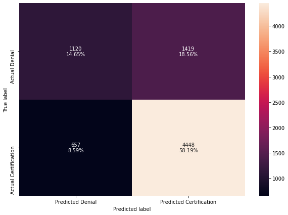

```python
#showing the confusion matrix for the tuned bagging classifier
confusion_matrix(grid, y_test)
```

I will now move on to the random forest model to see if the performance varies from these two models.

#### 1.3 Random Forest

```python
#building the random forest classifier
rf_estimator = RandomForestClassifier(random_state = 1)
rf_estimator.fit(x_train,y_train)
```

```
RandomForestClassifier(random_state=1)
```

```python
#getting the performance metrics for the random forest classifier
rf_score = metrics_score(rf_estimator)
```

```
Accuracy on training set :  1.0
Accuracy on test set :  0.7214809000523287
Recall on training set :  1.0
Recall on test set :  0.8331047992164544
Precision on training set :  1.0
Precision on test set :  0.7690777576853526
F1 Score on the training set :  1.0
F1 Score on the test set :  0.7998119417019276
```

It achieved an f1 score of ~80%. I will visualize this with a confusion matrix.

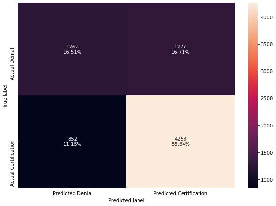

```python
#visualizing the performance of the random forest classifier with a confusion matrix
confusion_matrix(rf_estimator, y_test)
```

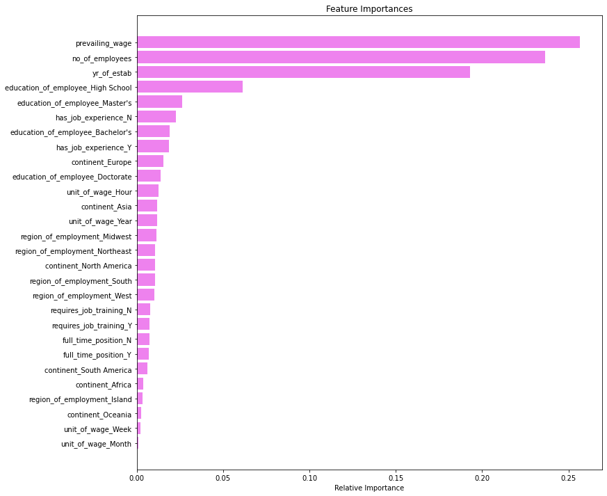

```python
#graphing the feature importances for the untuned random forest
importances = rf_estimator.feature_importances_
indices = np.argsort(importances)

plt.figure(figsize=(12,12))
plt.title('Feature Importances')
plt.barh(range(len(indices)), importances[indices], color='violet', align='center')
plt.yticks(range(len(indices)), [feature_names[i] for i in indices])
plt.xlabel('Relative Importance')
plt.show()
```

This shows that the feature importances for the untuned random forest classifier are almost identical to the importances from the original decision tree. The top four features in terms of importance are the same, but the attainment of an educational level up to a Master's degree has switched places with not having previous job experience. I will now tune the classifier to see if this improves the performance and changes the importance of the features.

```python
# Choosing the classifier
rf_estimator1 = RandomForestClassifier(random_state=1)

# Grid of parameters to choose from
parameters = {
        "max_depth": list(np.arange(5, 15, 5)),
        "max_features": ["sqrt", "log2"],
        "min_samples_split": [3, 5, 7],
        "n_estimators": np.arange(10, 40, 10),
        "max_depth" : [5,6,7]
}

# Run the grid search
grid_obj = GridSearchCV(rf_estimator1, parameters, scoring='f1',cv=5)
grid_obj = grid_obj.fit(x_train, y_train)

# Set the clf to the best combination of parameters
tuned_rf = grid_obj.best_estimator_

# Fit the best algorithm to the data.
tuned_rf.fit(x_train, y_train)
```

```
RandomForestClassifier(max_depth=7, max_features='sqrt', min_samples_split=5,
                       n_estimators=20, random_state=1)
```

```python
#showing the performance metrics for the tuned random forest classifier
tuned_rf_score = metrics_score(tuned_rf)
```

```
Accuracy on training set :  0.7489908051132541
Accuracy on test set :  0.7362637362637363
Recall on training set :  0.9174011583983883
Recall on test set :  0.910871694417238
Precision on training set :  0.7578005824434891
Precision on test set :  0.748671711479633
F1 Score on the training set :  0.8299981013859882
F1 Score on the test set :  0.821845174973489
```

By tuning the random forest I have eliminated almost all overfitting, as the performance on the training sets are only slightly higher than on the testing sets across all metrics. It delivered an f1 scoe of .822, which is the highest scoreachieved so far despite limiting its depth.

I will now print the confusion matrix of the tuned random forest classifier

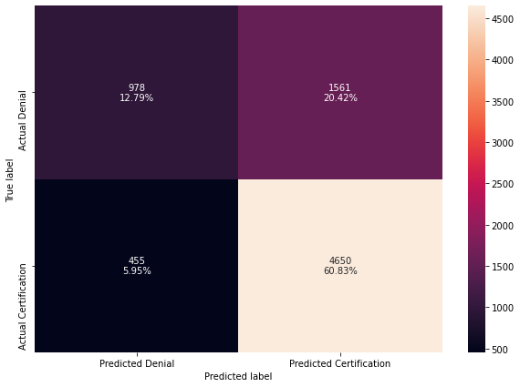

```python
#showing the confusion matrix of the tuned forest
confusion_matrix(tuned_rf, y_test)
```

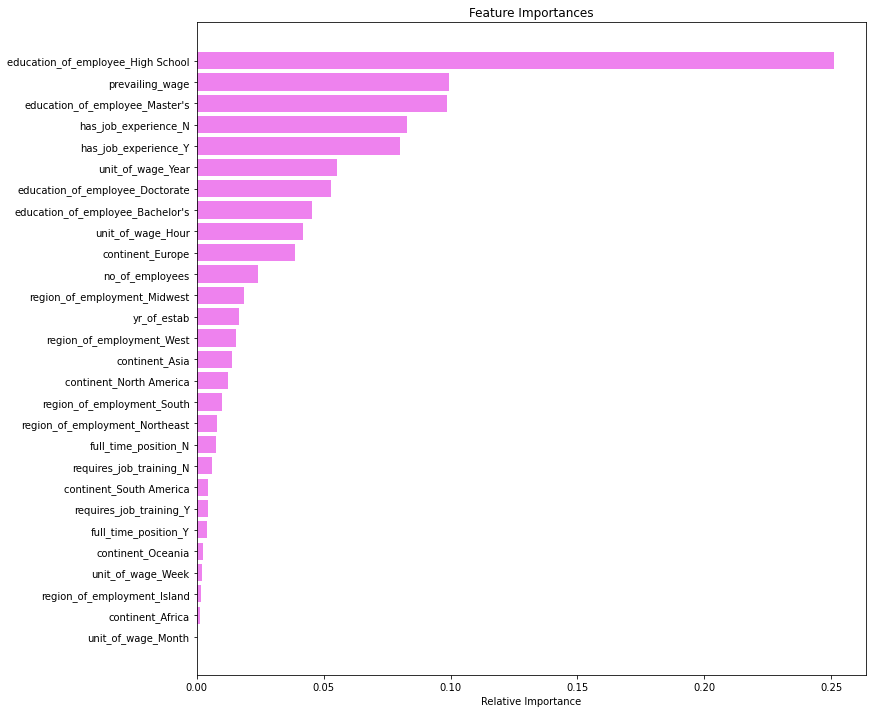

```python
#showing the values of the feature importance for the tuned random forest
importances = tuned_rf.feature_importances_
indices = np.argsort(importances)

plt.figure(figsize=(12,12))
plt.title('Feature Importances')
plt.barh(range(len(indices)), importances[indices], color='violet', align='center')
plt.yticks(range(len(indices)), [feature_names[i] for i in indices])
plt.xlabel('Relative Importance')
plt.show()
```

Interestingly, many of the features from the untuned random forest remain important for the tuned random forest, unlike on the tuned decision tree, where many of the features appeared to simply be dropped from the model.

The five most important features were:

1. if the applicant had only attained a high school education
2. the prevailing wage of the position applied to
3. If the applicant had only attained a Master's degree
4. the applicant not having job experience
5. the applicant having job experience

I will summarize the results from the three bagging models below.

### Bagging Model Comparison Summary

```python
#constructing and printing a dataframe showing all the results of the bagging models
bag_model_compare = pd.DataFrame({'Decision Tree':metrics_score(dTree, flag = False),
                                  'Tuned Tree':metrics_score(tuned_dTree, flag = False),
                                 'Bagging Classifier': metrics_score(bag, flag = False),
                                  'Tuned Bagging Classifier': metrics_score(grid, flag = False),
                                 'Random Forest': metrics_score(rf_estimator, flag = False),
                                 'Tuned RF': metrics_score(tuned_rf, flag = False)},

                                 index = ['Training Accuracy', 'Testing Accuracy', 'Training Recall',
                                         'Testing Recall', 'Training Precision', 'Testing Precision',
                                         'Training F1 Score', 'Testing F1 Score'])
bag_model_compare
```

|  | Decision Tree | Tuned Tree | Bagging Classifier | Tuned Bagging Classifier | Random Forest | Tuned RF |
| --- | --- | --- | --- | --- | --- | --- |
| Training Accuracy | 1.000000 | 0.734806 | 0.983573 | 0.945549 | 1.000000 | 0.748991 |
| Testing Accuracy | 0.658817 | 0.727106 | 0.700942 | 0.810791 | 0.721481 | 0.736264 |
| Training Recall | 1.000000 | 0.903635 | 0.984555 | 0.982456 | 1.000000 | 0.917401 |
| Testing Recall | 0.738100 | 0.902057 | 0.774535 | 0.871303 | 0.833105 | 0.910872 |
| Training Precision | 1.000000 | 0.750331 | 0.990792 | 0.911314 | 1.000000 | 0.757801 |
| Testing Precision | 0.747767 | 0.743822 | 0.776970 | 0.758139 | 0.769078 | 0.748672 |
| Training F1 Score | 1.000000 | 0.819878 | 0.987664 | 0.945549 | 1.000000 | 0.829998 |
| Testing F1 Score | 0.742902 | 0.815333 | 0.775750 | 0.810791 | 0.799812 | 0.821845 |

I will now move on to constructing boosting models to see if the performance can be even more improved from here.

## 2. Boosting Models

**2.1 AdaBoost Classifier**

```python
#building the Adaboost Classifier
aboost=AdaBoostClassifier(random_state=1)
aboost.fit(x_train,y_train)
```

```
AdaBoostClassifier(random_state=1)
```

```python
#printing the performance metrics of the adaboost classifier
aboost_score = metrics_score(aboost)
```

```
Accuracy on training set :  0.738394258802422
Accuracy on test set :  0.7337781266352695
Recall on training set :  0.8881054310417191
Recall on test set :  0.8850146914789422
Precision on training set :  0.7604398763746136
Precision on test set :  0.7572913174656386
F1 Score on the training set :  0.8193293580113065
F1 Score on the test set :  0.8161864330232138
```

This untuned adaboost model does not appear to suffer at all from overfitting. It achieved an f1 score of .816.

I will show the confusion matrix for the adaboost classifier.

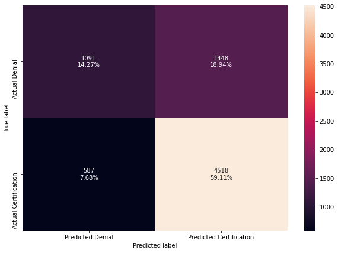

```python
#printing the confusion matrix of the results of the adaboost classifier
confusion_matrix(aboost, y_test)
```

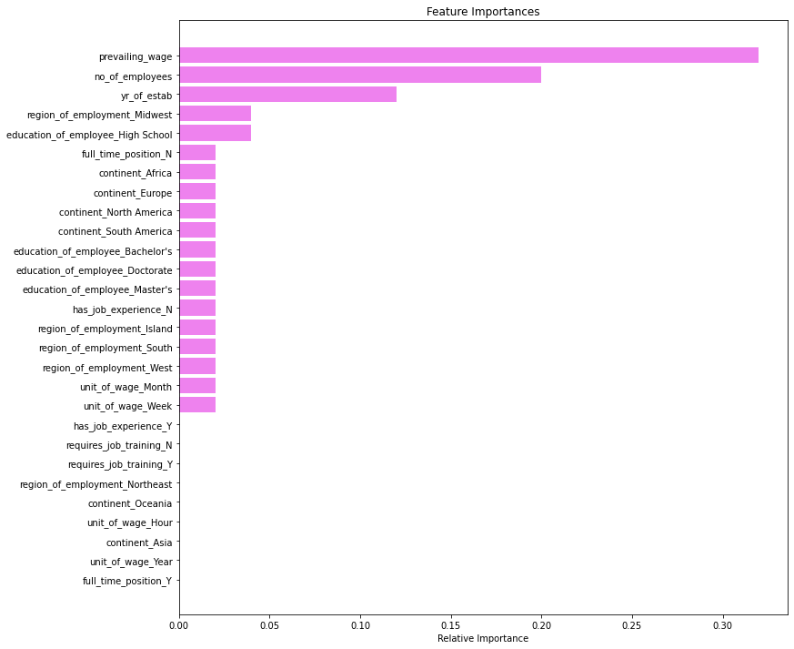

```python
#showing the feature importances for the adaboost classifier
importances = aboost.feature_importances_
indices = np.argsort(importances)

plt.figure(figsize=(12,12))
plt.title('Feature Importances')
plt.barh(range(len(indices)), importances[indices], color='violet', align='center')
plt.yticks(range(len(indices)), [feature_names[i] for i in indices])
plt.xlabel('Relative Importance')
plt.show()
```

This is an interesting result, as it appears that, after the 5 most important features (whose importances vary) all the remaining important features are of equal importance, somewhere around .02 it looks like.

The most important features of this model are:

1. the prevailing wage
2. the number of employees in the company
3. the year of establishment of the company
4. if the applicant was joining a company in the midwest
5. if the applicant attained only high school

Next I will tune the model to see what effect this has on the performance as well as on the importance of the features.

```python
# assigning the adaboost classifier
tuned_aboost = AdaBoostClassifier(random_state=1)

# Grid of parameters to choose from
parameters = {'n_estimators': np.arange(10,100,10),
              'learning_rate': [1, 0.1, 0.5, 0.01],
              }

# Type of scoring used to compare parameter combinations
scorer = metrics.make_scorer(metrics.f1_score)

# Run the grid search
grid_obj = GridSearchCV(tuned_aboost, parameters, scoring=scorer,cv=5)
grid_obj = grid_obj.fit(x_train, y_train)

# Set the clf to the best combination of parameters
tuned_aboost = grid_obj.best_estimator_

# Fit the best algorithm to the data.
tuned_aboost.fit(x_train, y_train)
```

```
AdaBoostClassifier(learning_rate=0.5, n_estimators=30, random_state=1)
```

```python
#checking the performance metrics on the tuned adaboost classifier
tuned_aboost_score = metrics_score(tuned_aboost)
```

```
Accuracy on training set :  0.7394034536891679
Accuracy on test set :  0.7348246991104134
Recall on training set :  0.88886090825149
Recall on test set :  0.8865817825661116
Precision on training set :  0.7610867533961043
Precision on test set :  0.7576163374623368
F1 Score on the training set :  0.8200263300549834
F1 Score on the test set :  0.8170412492102176
```

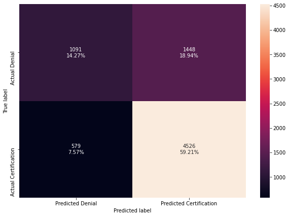

```python
#showing the confusion matrix of the tuned adaboost classifier
confusion_matrix(tuned_aboost, y_test)
```

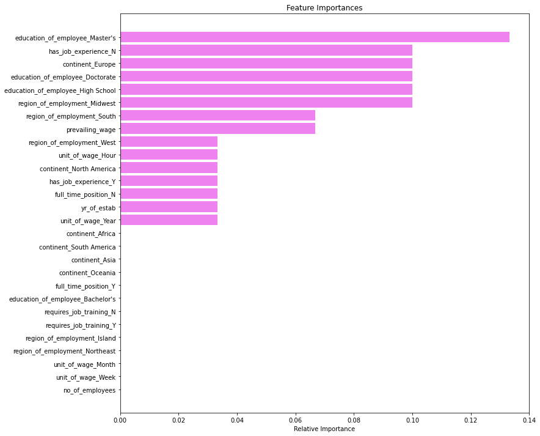

```python
#showing the feature importances for the tuned adaboost classifier
importances = tuned_aboost.feature_importances_
indices = np.argsort(importances)

plt.figure(figsize=(12,12))
plt.title('Feature Importances')
plt.barh(range(len(indices)), importances[indices], color='violet', align='center')
plt.yticks(range(len(indices)), [feature_names[i] for i in indices])
plt.xlabel('Relative Importance')
plt.show()
```

Tuning the AbaBoost Classifier generated interesting relative importance values for the classifier's features. There were 15 features out of the 28 that had any importance at all, and those 15 were separated into only 4 groups of equal relative importance. The most important feature had a relative importance of just over .13; it was if the applicant had achieved up to a Master's education.

I will now visualize the confusion matrix.

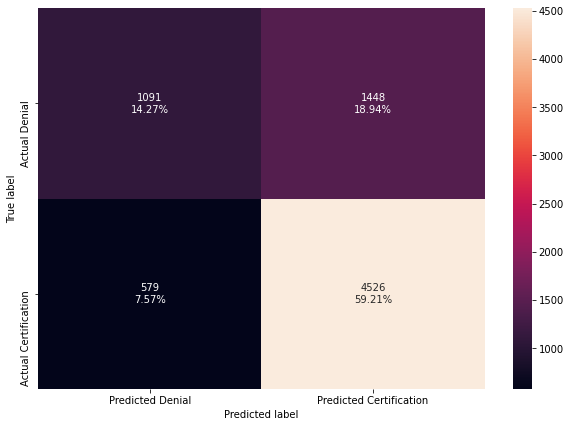

```python
#showing the confusion matrix for the tuned adaboost model
confusion_matrix(tuned_aboost, y_test)
```

**2.2 Gradient Boosting Classifier**

```python
#building the gradient boosting classifier
gboost = GradientBoostingClassifier(random_state = 1)
gboost.fit(x_train,y_train)
```

```
GradientBoostingClassifier(random_state=1)
```

```python
#printing the performance metrics of the gradient boosting classifier
gboost_score = metrics_score(gboost)
```

```
Accuracy on training set :  0.7561673020856694
Accuracy on test set :  0.7458137100994244
Recall on training set :  0.8803827751196173
Recall on test set :  0.8763956904995103
Precision on training set :  0.7819862809424396
Precision on test set :  0.773245765641203
F1 Score on the training set :  0.8282724580454097
F1 Score on the test set :  0.8215958130566524
```

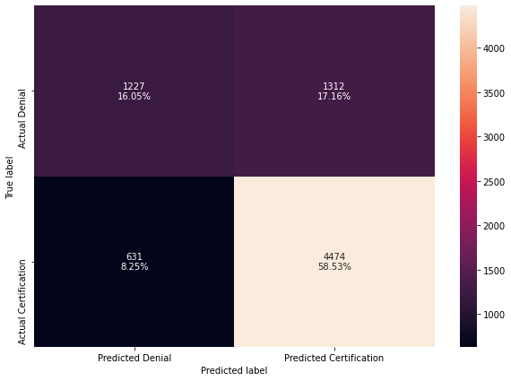

```python
#printing the confusion matrix of the gradient boosting classifier
confusion_matrix(gboost,y_test)
```

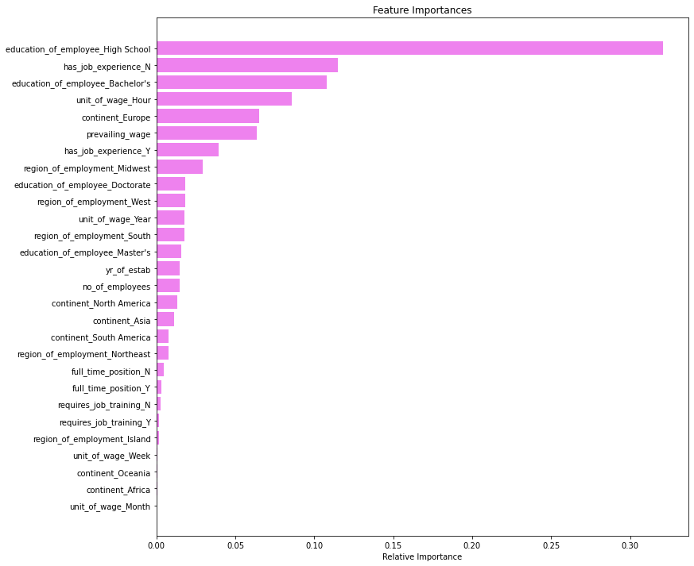

```python
#printing the feature importances of the gradient boosting classifier
importances = gboost.feature_importances_
indices = np.argsort(importances)

plt.figure(figsize=(12,12))
plt.title('Feature Importances')
plt.barh(range(len(indices)), importances[indices], color='violet', align='center')
plt.yticks(range(len(indices)), [feature_names[i] for i in indices])
plt.xlabel('Relative Importance')
plt.show()
```

The five most important features in the Gradient Boosting Classifierd are:

1. if an applicant has only attained a high school diploma
2. if they do not have previous job experience
3. if they have achieved only a Bachelor's degree
4. if they are paid hourly
5. if they are applying from Europe

I will now tune the Gradient Boosting Classifier to see how it affects performance and feature importance.

```python
# Choosing the Gradient Boosting classifier.
tuned_gboost = GradientBoostingClassifier(init = AdaBoostClassifier(random_state = 1),random_state=1)

# parameter grid
parameters = {"n_estimators": [200, 250, 300],
                "subsample": [0.8, 0.9, 1],
                "max_features": [0.7, 0.8, 0.9, 1],
                "max_depth": [5]
              }

# Type of scoring used to compare parameter combinations
scorer = metrics.make_scorer(metrics.f1_score)

# Run the grid search
grid_obj = GridSearchCV(tuned_gboost, parameters, scoring=scorer,cv=5)
grid_obj = grid_obj.fit(x_train, y_train)

# Set the clf to the best combination of parameters
tuned_gboost = grid_obj.best_estimator_

# Fit the best algorithm to the data.
tuned_gboost.fit(x_train, y_train)
```

```
GradientBoostingClassifier(init=AdaBoostClassifier(random_state=1), max_depth=5,
                           max_features=1, n_estimators=200, random_state=1,
                           subsample=0.8)
```

```python
#getting the performance metrics for the tuned gradient boosting classifier
tuned_gboost_score = metrics_score(tuned_gboost)
```

```
Accuracy on training set :  0.7698474994393362
Accuracy on test set :  0.7448979591836735
Recall on training set :  0.884999580290439
Recall on test set :  0.8693437806072478
Precision on training set :  0.7940201837626149
Precision on test set :  0.7757385072539765
F1 Score on the training set :  0.8370449763804533
F1 Score on the test set :  0.8198780713098097
```

The tuning of the Gradient Boosting Classifier results neither in a reduction of overfitting nor in an improvement in the f1 score. The f1 score on the tuned Gradient Boosting Classifier is slightly lower than the untuned one at only .82.

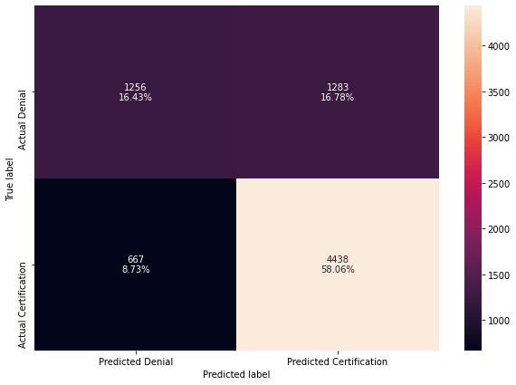

```python
#showing the confusion matrix for the tuned gradient boosting classifier
confusion_matrix(tuned_gboost, y_test)
```

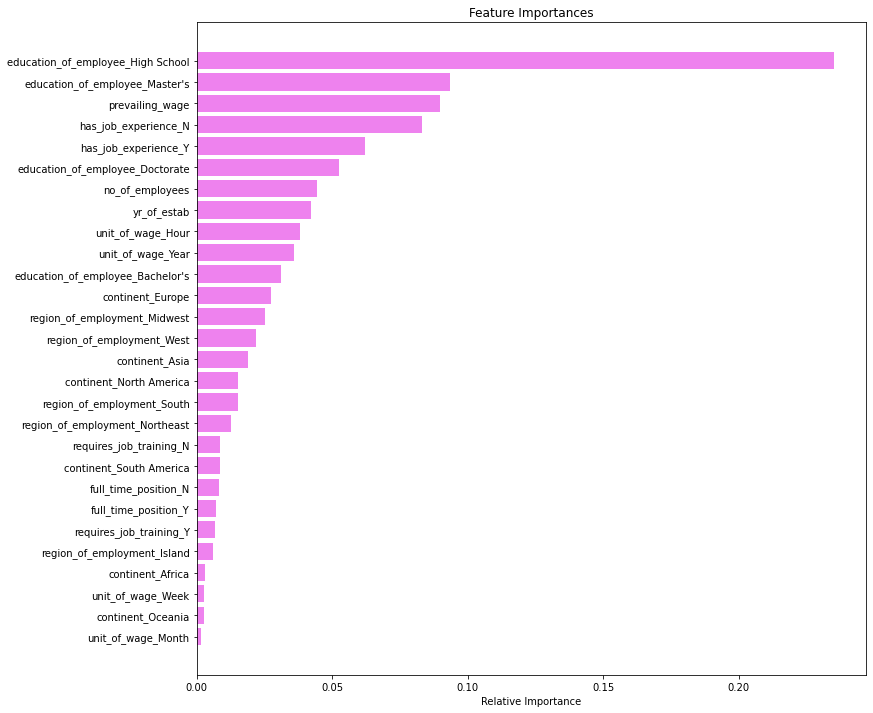

```python
#showing the feature importances for the tuned gradient boosting model
importances = tuned_gboost.feature_importances_
indices = np.argsort(importances)

plt.figure(figsize=(12,12))
plt.title('Feature Importances')
plt.barh(range(len(indices)), importances[indices], color='violet', align='center')
plt.yticks(range(len(indices)), [feature_names[i] for i in indices])
plt.xlabel('Relative Importance')
plt.show()
```

**2.3 Stacking Classifier**

```python
#determining the estimators
estimators=[('Decision Tree',tuned_dTree),('Random Forest', tuned_rf),('AdaBoost', tuned_aboost)]
#determining the final estimator (model with the best performance)
final_estimator=gboost
```

```python
#making the stacking classifier
stacker = StackingClassifier(estimators = estimators, final_estimator = final_estimator, cv = 5)
stacker.fit(x_train,y_train)
```

```
StackingClassifier(cv=5,
                   estimators=[('Decision Tree',
                                DecisionTreeClassifier(max_depth=4,
                                                       max_leaf_nodes=10,
                                                       min_impurity_decrease=0.001,
                                                       random_state=1)),
                               ('Random Forest',
                                RandomForestClassifier(max_depth=7,
                                                       max_features='sqrt',
                                                       min_samples_split=5,
                                                       n_estimators=20,
                                                       random_state=1)),
                               ('AdaBoost',
                                AdaBoostClassifier(learning_rate=0.5,
                                                   n_estimators=30,
                                                   random_state=1))],
                   final_estimator=GradientBoostingClassifier(random_state=1))
```

```python
#showing the performance metrics for the stacking classifier
stacker_score = metrics_score(stacker)
```

```
Accuracy on training set :  0.7551020408163265
Accuracy on test set :  0.7429356357927787
Recall on training set :  0.8743389574414505
Recall on test set :  0.8656219392752204
Precision on training set :  0.7839241363738993
Precision on test set :  0.7755352755352756
F1 Score on the training set :  0.8266666666666667
F1 Score on the test set :  0.8181060816439878
```

The f1 score on the stacker is slightly lower than it was in either the gradient boost or its tuned version, so it is not the model that generates the best performance.

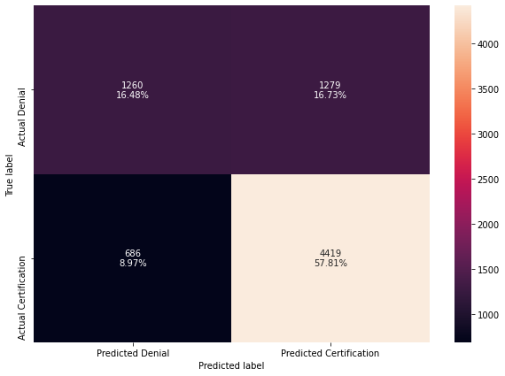

```python
#showing the confusion matrix for the stacking classifier
confusion_matrix(stacker, y_test)
```

### Boosting Model Comparison Summary

```python
#constructing and printing a dataframe showing all the results of the bagging models
boost_model_compare = pd.DataFrame({'AdaBoost':metrics_score(aboost, flag = False),
                                  'Tuned AdaBoost':metrics_score(tuned_aboost, flag = False),
                                 'Gradient Boost': metrics_score(gboost, flag = False),
                                  'Tuned Gradient Boost': metrics_score(tuned_gboost, flag = False),
                                 'Stacking': metrics_score(stacker, flag = False)},

                                 index = ['Training Accuracy', 'Testing Accuracy', 'Training Recall',
                                         'Testing Recall', 'Training Precision', 'Testing Precision',
                                         'Training F1 Score', 'Testing F1 Score'])
boost_model_compare
```

|  | AdaBoost | Tuned AdaBoost | Gradient Boost | Tuned Gradient Boost | Stacking |
| --- | --- | --- | --- | --- | --- |
| Training Accuracy | 0.738394 | 0.739403 | 0.756167 | 0.769847 | 0.755102 |
| Testing Accuracy | 0.733778 | 0.734825 | 0.745814 | 0.744898 | 0.742936 |
| Training Recall | 0.888105 | 0.888861 | 0.880383 | 0.885000 | 0.874339 |
| Testing Recall | 0.885015 | 0.886582 | 0.876396 | 0.869344 | 0.865622 |
| Training Precision | 0.760440 | 0.761087 | 0.781986 | 0.794020 | 0.783924 |
| Testing Precision | 0.757291 | 0.757616 | 0.773246 | 0.775739 | 0.775535 |
| Training F1 Score | 0.819329 | 0.820026 | 0.828272 | 0.837045 | 0.826667 |
| Testing F1 Score | 0.816186 | 0.817041 | 0.821596 | 0.819878 | 0.818106 |

The best performance was from the Gradient Boosting Classifier, which generated an f1 score of 0.821. The worst performing model of the boosting models was the untuned adaboost model, which generated an f1 score of 0.816, followed by the tuned adaboost model with an f1 score of 0.8170, then the Stacking classifier with an f1 score of 0.818, then the tuned gradient boosting classifier with an f1 score of 0.819.

I will now show how the boosting models compare in performance with the bagging models.

## Model Performance Comparison and Conclusions

```python
#combining the dataframes comparing bagging and boosting model performance
bag_boost_compare = pd.concat([bag_model_compare, boost_model_compare], axis = 1)
bag_boost_compare
```

|  | Decision Tree | Tuned Tree | Bagging Classifier | Tuned Bagging Classifier | Random Forest | Tuned RF | AdaBoost | Tuned AdaBoost | Gradient Boost | Tuned Gradient Boost | Stacking |
| --- | --- | --- | --- | --- | --- | --- | --- | --- | --- | --- | --- |
| Training Accuracy | 1.000000 | 0.734806 | 0.983573 | 0.945549 | 1.000000 | 0.748991 | 0.738394 | 0.739403 | 0.756167 | 0.769847 | 0.755102 |
| Testing Accuracy | 0.658817 | 0.727106 | 0.700942 | 0.810791 | 0.721481 | 0.736264 | 0.733778 | 0.734825 | 0.745814 | 0.744898 | 0.742936 |
| Training Recall | 1.000000 | 0.903635 | 0.984555 | 0.982456 | 1.000000 | 0.917401 | 0.888105 | 0.888861 | 0.880383 | 0.885000 | 0.874339 |
| Testing Recall | 0.738100 | 0.902057 | 0.774535 | 0.871303 | 0.833105 | 0.910872 | 0.885015 | 0.886582 | 0.876396 | 0.869344 | 0.865622 |
| Training Precision | 1.000000 | 0.750331 | 0.990792 | 0.911314 | 1.000000 | 0.757801 | 0.760440 | 0.761087 | 0.781986 | 0.794020 | 0.783924 |
| Testing Precision | 0.747767 | 0.743822 | 0.776970 | 0.758139 | 0.769078 | 0.748672 | 0.757291 | 0.757616 | 0.773246 | 0.775739 | 0.775535 |
| Training F1 Score | 1.000000 | 0.819878 | 0.987664 | 0.945549 | 1.000000 | 0.829998 | 0.819329 | 0.820026 | 0.828272 | 0.837045 | 0.826667 |
| Testing F1 Score | 0.742902 | 0.815333 | 0.775750 | 0.810791 | 0.799812 | 0.821845 | 0.816186 | 0.817041 | 0.821596 | 0.819878 | 0.818106 |

```python
#printing a list of the best-to-worst performing models
print('Models in terms of highest to lowest f1 score:\n')
bag_boost_compare.loc['Testing F1 Score'].sort_values(ascending = False)
```

```
Models in terms of highest to lowest f1 score:
```

```
Tuned RF                    0.821845
Gradient Boost              0.821596
Tuned Gradient Boost        0.819878
Stacking                    0.818106
Tuned AdaBoost              0.817041
AdaBoost                    0.816186
Tuned Tree                  0.815333
Tuned Bagging Classifier    0.810791
Random Forest               0.799812
Bagging Classifier          0.775750
Decision Tree               0.742902
Name: Testing F1 Score, dtype: float64
```

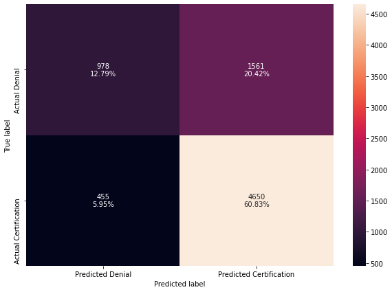

```python
#printing a confusion matrix of the Gradient Boosting Classifier, the best performing model
confusion_matrix(tuned_rf, y_test)
```

According to our desired metric (f1 score), this model does the best job of maximizing true positives while taking into account the need to minimize false negatives.

It correctly predicts 4650 certifications and only falsely predicts 1561. It correctly predicts 978 denials and only incorrectly predicts 455 denials. The number of correct predictions is ~73%, while the model makes incorrect predictions only just above 1/4 of the time.

I will now print the feature importances for this model so that I can make recommendations accordingly.

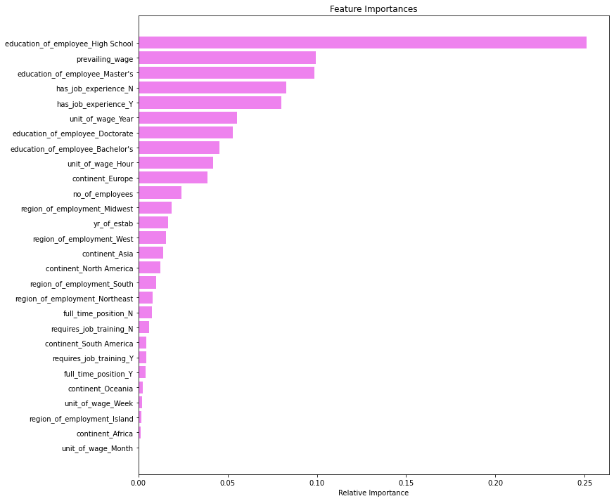

```python
#printing the feature importances of the gradient boosting classifier
importances = tuned_rf.feature_importances_
indices = np.argsort(importances)

plt.figure(figsize=(12,12))
plt.title('Feature Importances')
plt.barh(range(len(indices)), importances[indices], color='violet', align='center')
plt.yticks(range(len(indices)), [feature_names[i] for i in indices])
plt.xlabel('Relative Importance')
plt.show()
```

## Actionable Insights and Recommendations

**In order to identify visas that are likely to be certified or denied, consider the following points:**

- If an applicant has only a high school degree and no previous job experience, that visa application should be moved to the bottom of the list.
- If the employee meets the above criteria and is going to be paid hourly, it would be generally good practice to move that application to the bottom of the list.
- If the applicant has obtained a doctorate, it is generally a good idea to move their application to the top of the list.
- If an application is for a position where the prevailing wage is on the higher end, that application should be moved ahead of positions with lower prevailing wages.
- If the applicant does not require on-the-job training, and they already have experience, then their application can be moved up the list.
- If the candidate is from Europe or Oceania, they will have a higher chance of being certified, especially if they have higher than a high-school degree.

**The ideal profile for a visa applicant would be:**

- Someone from Europe or Oceania
- with at least a Master's,
- previous job experience,
- in a position for which there is a prevailing wage of at least 70,000 per year,
- and requires no job training.

**Candidates whose applications should be considered unlikely for approval will be:**

- those who work for hourly compensation;
- those who have only attained a high-school level of education;
- those who applied for work in positions with lower prevailing wages; and
- those who require training and have no previous experience.